# Risk Factor Analysis

## Outcome Variable

**Outcome Variable:** sstunted

## Predictor Variables

**Intervention Variable:** sex

**Adjustment Set:**

unadjusted

## Stratifying Variables

The analysis was stratified on these variable(s):

- agecat
- studyid
- country

## Data Summary

| agecat | studyid | country | sex | sstunted | n_cell | n |
| --- | --- | --- | --- | --- | --- | --- |
| Birth | CMC-V-BCS-2002 | INDIA | Female | 0 | 45 | 92 |
| Birth | CMC-V-BCS-2002 | INDIA | Female | 1 | 1 | 92 |
| Birth | CMC-V-BCS-2002 | INDIA | Male | 0 | 43 | 92 |
| Birth | CMC-V-BCS-2002 | INDIA | Male | 1 | 3 | 92 |
| Birth | CMIN | BANGLADESH | Female | 0 | 9 | 26 |
| Birth | CMIN | BANGLADESH | Female | 1 | 2 | 26 |
| Birth | CMIN | BANGLADESH | Male | 0 | 11 | 26 |
| Birth | CMIN | BANGLADESH | Male | 1 | 4 | 26 |
| Birth | COHORTS | GUATEMALA | Female | 0 | 400 | 852 |
| Birth | COHORTS | GUATEMALA | Female | 1 | 4 | 852 |
| Birth | COHORTS | GUATEMALA | Male | 0 | 441 | 852 |
| Birth | COHORTS | GUATEMALA | Male | 1 | 7 | 852 |
| Birth | COHORTS | INDIA | Female | 0 | 3101 | 6640 |
| Birth | COHORTS | INDIA | Female | 1 | 94 | 6640 |
| Birth | COHORTS | INDIA | Male | 0 | 3333 | 6640 |
| Birth | COHORTS | INDIA | Male | 1 | 112 | 6640 |
| Birth | COHORTS | PHILIPPINES | Female | 0 | 1415 | 3050 |
| Birth | COHORTS | PHILIPPINES | Female | 1 | 18 | 3050 |
| Birth | COHORTS | PHILIPPINES | Male | 0 | 1589 | 3050 |
| Birth | COHORTS | PHILIPPINES | Male | 1 | 28 | 3050 |
| Birth | CONTENT | PERU | Female | 0 | 0 | 2 |
| Birth | CONTENT | PERU | Female | 1 | 0 | 2 |
| Birth | CONTENT | PERU | Male | 0 | 2 | 2 |
| Birth | CONTENT | PERU | Male | 1 | 0 | 2 |
| Birth | EE | PAKISTAN | Female | 0 | 99 | 240 |
| Birth | EE | PAKISTAN | Female | 1 | 23 | 240 |
| Birth | EE | PAKISTAN | Male | 0 | 93 | 240 |
| Birth | EE | PAKISTAN | Male | 1 | 25 | 240 |
| Birth | GMS-Nepal | NEPAL | Female | 0 | 313 | 696 |
| Birth | GMS-Nepal | NEPAL | Female | 1 | 15 | 696 |

[output cut: 298 more lines]

The following strata were considered:

- agecat: 24 months, studyid: CMC-V-BCS-2002, country: INDIA
- agecat: 24 months, studyid: CMIN, country: BANGLADESH
- agecat: 24 months, studyid: COHORTS, country: GUATEMALA
- agecat: 24 months, studyid: COHORTS, country: INDIA
- agecat: 24 months, studyid: COHORTS, country: PHILIPPINES
- agecat: 24 months, studyid: CONTENT, country: PERU
- agecat: 24 months, studyid: EE, country: PAKISTAN
- agecat: 24 months, studyid: GMS-Nepal, country: NEPAL
- agecat: 24 months, studyid: IRC, country: INDIA
- agecat: 24 months, studyid: JiVitA-3, country: BANGLADESH
- agecat: 24 months, studyid: JiVitA-4, country: BANGLADESH
- agecat: 24 months, studyid: Keneba, country: GAMBIA
- agecat: 24 months, studyid: LCNI-5, country: MALAWI
- agecat: 24 months, studyid: MAL-ED, country: BANGLADESH
- agecat: 24 months, studyid: MAL-ED, country: BRAZIL
- agecat: 24 months, studyid: MAL-ED, country: INDIA
- agecat: 24 months, studyid: MAL-ED, country: NEPAL
- agecat: 24 months, studyid: MAL-ED, country: PERU
- agecat: 24 months, studyid: MAL-ED, country: SOUTH AFRICA
- agecat: 24 months, studyid: MAL-ED, country: TANZANIA, UNITED REPUBLIC OF
- agecat: 24 months, studyid: NIH-Birth, country: BANGLADESH
- agecat: 24 months, studyid: NIH-Crypto, country: BANGLADESH
- agecat: 24 months, studyid: PROBIT, country: BELARUS
- agecat: 24 months, studyid: PROVIDE, country: BANGLADESH
- agecat: 24 months, studyid: TanzaniaChild2, country: TANZANIA, UNITED REPUBLIC OF
- agecat: 24 months, studyid: ZVITAMBO, country: ZIMBABWE
- agecat: 6 months, studyid: CMC-V-BCS-2002, country: INDIA
- agecat: 6 months, studyid: CMIN, country: BANGLADESH
- agecat: 6 months, studyid: COHORTS, country: GUATEMALA
- agecat: 6 months, studyid: COHORTS, country: INDIA
- agecat: 6 months, studyid: COHORTS, country: PHILIPPINES
- agecat: 6 months, studyid: CONTENT, country: PERU
- agecat: 6 months, studyid: EE, country: PAKISTAN
- agecat: 6 months, studyid: GMS-Nepal, country: NEPAL
- agecat: 6 months, studyid: Guatemala BSC, country: GUATEMALA
- agecat: 6 months, studyid: IRC, country: INDIA
- agecat: 6 months, studyid: JiVitA-3, country: BANGLADESH
- agecat: 6 months, studyid: JiVitA-4, country: BANGLADESH
- agecat: 6 months, studyid: Keneba, country: GAMBIA
- agecat: 6 months, studyid: LCNI-5, country: MALAWI
- agecat: 6 months, studyid: MAL-ED, country: BANGLADESH
- agecat: 6 months, studyid: MAL-ED, country: BRAZIL
- agecat: 6 months, studyid: MAL-ED, country: INDIA
- agecat: 6 months, studyid: MAL-ED, country: NEPAL
- agecat: 6 months, studyid: MAL-ED, country: PERU
- agecat: 6 months, studyid: MAL-ED, country: SOUTH AFRICA
- agecat: 6 months, studyid: MAL-ED, country: TANZANIA, UNITED REPUBLIC OF
- agecat: 6 months, studyid: NIH-Birth, country: BANGLADESH
- agecat: 6 months, studyid: NIH-Crypto, country: BANGLADESH
- agecat: 6 months, studyid: PROBIT, country: BELARUS
- agecat: 6 months, studyid: PROVIDE, country: BANGLADESH
- agecat: 6 months, studyid: ResPak, country: PAKISTAN
- agecat: 6 months, studyid: SAS-CompFeed, country: INDIA
- agecat: 6 months, studyid: SAS-FoodSuppl, country: INDIA
- agecat: 6 months, studyid: TanzaniaChild2, country: TANZANIA, UNITED REPUBLIC OF
- agecat: 6 months, studyid: ZVITAMBO, country: ZIMBABWE
- agecat: Birth, studyid: CMC-V-BCS-2002, country: INDIA
- agecat: Birth, studyid: CMIN, country: BANGLADESH
- agecat: Birth, studyid: COHORTS, country: GUATEMALA
- agecat: Birth, studyid: COHORTS, country: INDIA
- agecat: Birth, studyid: COHORTS, country: PHILIPPINES
- agecat: Birth, studyid: CONTENT, country: PERU
- agecat: Birth, studyid: EE, country: PAKISTAN
- agecat: Birth, studyid: GMS-Nepal, country: NEPAL
- agecat: Birth, studyid: IRC, country: INDIA
- agecat: Birth, studyid: JiVitA-3, country: BANGLADESH
- agecat: Birth, studyid: JiVitA-4, country: BANGLADESH
- agecat: Birth, studyid: Keneba, country: GAMBIA
- agecat: Birth, studyid: MAL-ED, country: BANGLADESH
- agecat: Birth, studyid: MAL-ED, country: BRAZIL
- agecat: Birth, studyid: MAL-ED, country: INDIA
- agecat: Birth, studyid: MAL-ED, country: NEPAL
- agecat: Birth, studyid: MAL-ED, country: PERU
- agecat: Birth, studyid: MAL-ED, country: SOUTH AFRICA
- agecat: Birth, studyid: MAL-ED, country: TANZANIA, UNITED REPUBLIC OF
- agecat: Birth, studyid: NIH-Birth, country: BANGLADESH
- agecat: Birth, studyid: NIH-Crypto, country: BANGLADESH
- agecat: Birth, studyid: PROBIT, country: BELARUS
- agecat: Birth, studyid: PROVIDE, country: BANGLADESH
- agecat: Birth, studyid: ResPak, country: PAKISTAN
- agecat: Birth, studyid: SAS-CompFeed, country: INDIA
- agecat: Birth, studyid: ZVITAMBO, country: ZIMBABWE

### Dropped Strata

Some strata were dropped due to rare outcomes:

- agecat: Birth, studyid: CMC-V-BCS-2002, country: INDIA
- agecat: Birth, studyid: CMIN, country: BANGLADESH
- agecat: Birth, studyid: COHORTS, country: GUATEMALA
- agecat: Birth, studyid: CONTENT, country: PERU
- agecat: Birth, studyid: MAL-ED, country: BANGLADESH
- agecat: Birth, studyid: MAL-ED, country: BRAZIL
- agecat: Birth, studyid: MAL-ED, country: INDIA
- agecat: Birth, studyid: MAL-ED, country: NEPAL
- agecat: Birth, studyid: MAL-ED, country: PERU
- agecat: Birth, studyid: MAL-ED, country: SOUTH AFRICA
- agecat: Birth, studyid: MAL-ED, country: TANZANIA, UNITED REPUBLIC OF
- agecat: Birth, studyid: NIH-Crypto, country: BANGLADESH
- agecat: Birth, studyid: PROBIT, country: BELARUS
- agecat: Birth, studyid: PROVIDE, country: BANGLADESH
- agecat: Birth, studyid: ResPak, country: PAKISTAN
- agecat: 6 months, studyid: CONTENT, country: PERU
- agecat: 6 months, studyid: GMS-Nepal, country: NEPAL
- agecat: 6 months, studyid: MAL-ED, country: BANGLADESH
- agecat: 6 months, studyid: MAL-ED, country: BRAZIL
- agecat: 6 months, studyid: MAL-ED, country: INDIA
- agecat: 6 months, studyid: MAL-ED, country: NEPAL
- agecat: 6 months, studyid: MAL-ED, country: PERU
- agecat: 6 months, studyid: MAL-ED, country: SOUTH AFRICA
- agecat: 6 months, studyid: MAL-ED, country: TANZANIA, UNITED REPUBLIC OF
- agecat: 6 months, studyid: PROVIDE, country: BANGLADESH
- agecat: 24 months, studyid: CONTENT, country: PERU
- agecat: 24 months, studyid: MAL-ED, country: BRAZIL
- agecat: 24 months, studyid: MAL-ED, country: NEPAL
- agecat: 24 months, studyid: MAL-ED, country: PERU
- agecat: 24 months, studyid: TanzaniaChild2, country: TANZANIA, UNITED REPUBLIC OF

## Methods Detail

We’re interested in the causal parameters $E[Y_a]$ for all values of $a \in \mathcal{A}$. These parameters represent the mean outcome if, possibly contrary to fact, we intervened to set all units to have $A=a$. Under the randomization and positivity assumptions, these are identified by the statistical parameters $\psi_a=E_W[E_{Y|A,W}(Y|A=a,W)]$. In addition, we’re interested in the mean of $Y$, $E[Y]$ under no intervention (the observed mean). We will estimate these parameters by using SuperLearner to fit the relevant likelihood factors – $E_{Y|A,W}(Y|A=a,W)$ and $p(A=a|W)$, and then updating our likelihood fit using a joint TMLE.

For unadjusted analyses ($W=\{\}$), initial likelihoods were estimated using Lrnr_glm to estimate the simple $E(Y|A)$ and Lrnr_mean to estimate $p(A)$. For adjusted analyses, a small library containing Lrnr_glmnet, Lrnr_xgboost, and Lrnr_mean was used.

Having estimated these parameters, we will then use the delta method to estimate relative risks and attributable risks relative to a prespecified baseline level of $A$.

# Results Detail

## Results Plots

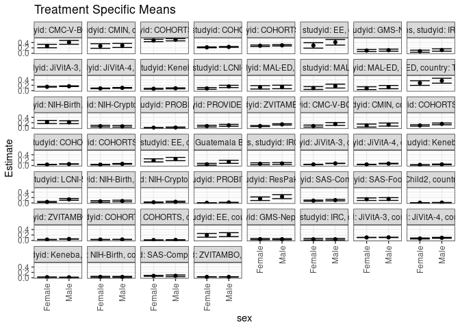

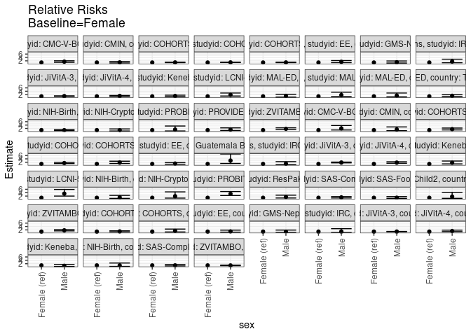

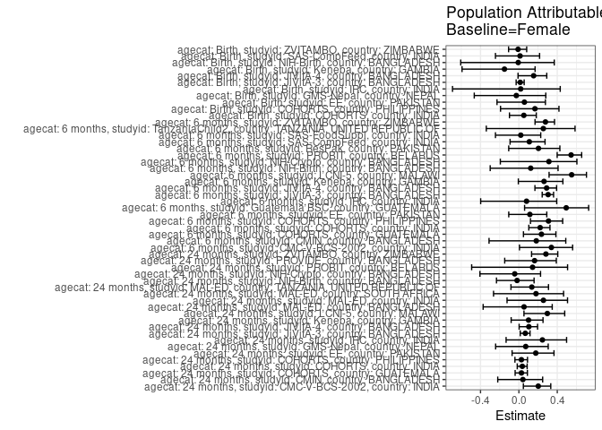

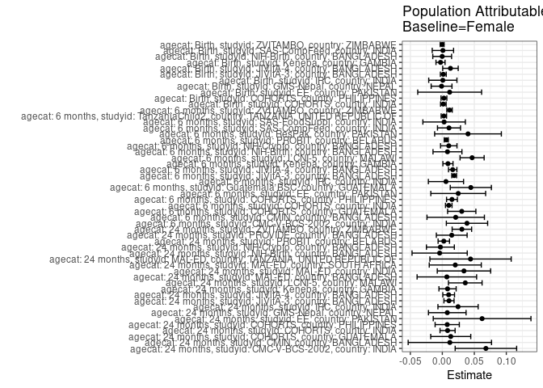

## Results Table

### Parameter: TSM

| agecat | studyid | country | intervention_level | baseline_level | estimate | ci_lower | ci_upper |
| --- | --- | --- | --- | --- | --- | --- | --- |
| Birth | COHORTS | INDIA | Female | NA | 0.0294210 | 0.0235611 | 0.0352809 |
| Birth | COHORTS | INDIA | Male | NA | 0.0325109 | 0.0265881 | 0.0384336 |
| Birth | COHORTS | PHILIPPINES | Female | NA | 0.0125611 | 0.0067939 | 0.0183283 |
| Birth | COHORTS | PHILIPPINES | Male | NA | 0.0173160 | 0.0109569 | 0.0236751 |
| Birth | EE | PAKISTAN | Female | NA | 0.1885246 | 0.1189747 | 0.2580745 |
| Birth | EE | PAKISTAN | Male | NA | 0.2118644 | 0.1379816 | 0.2857472 |
| Birth | GMS-Nepal | NEPAL | Female | NA | 0.0457317 | 0.0231078 | 0.0683556 |
| Birth | GMS-Nepal | NEPAL | Male | NA | 0.0434783 | 0.0226276 | 0.0643289 |
| Birth | IRC | INDIA | Female | NA | 0.0404624 | 0.0110628 | 0.0698621 |
| Birth | IRC | INDIA | Male | NA | 0.0418605 | 0.0150561 | 0.0686648 |
| Birth | JiVitA-3 | BANGLADESH | Female | NA | 0.1074889 | 0.1010908 | 0.1138870 |
| Birth | JiVitA-3 | BANGLADESH | Male | NA | 0.1104977 | 0.1041103 | 0.1168851 |
| Birth | JiVitA-4 | BANGLADESH | Female | NA | 0.0698344 | 0.0527540 | 0.0869148 |
| Birth | JiVitA-4 | BANGLADESH | Male | NA | 0.0948396 | 0.0784805 | 0.1111987 |
| Birth | Keneba | GAMBIA | Female | NA | 0.0216216 | 0.0111390 | 0.0321043 |
| Birth | Keneba | GAMBIA | Male | NA | 0.0161893 | 0.0074576 | 0.0249210 |
| Birth | NIH-Birth | BANGLADESH | Female | NA | 0.0314685 | 0.0112189 | 0.0517182 |
| Birth | NIH-Birth | BANGLADESH | Male | NA | 0.0310559 | 0.0120933 | 0.0500186 |
| Birth | SAS-CompFeed | INDIA | Female | NA | 0.0717949 | 0.0533254 | 0.0902643 |
| Birth | SAS-CompFeed | INDIA | Male | NA | 0.0734633 | 0.0428391 | 0.1040874 |
| Birth | ZVITAMBO | ZIMBABWE | Female | NA | 0.0321339 | 0.0279275 | 0.0363402 |
| Birth | ZVITAMBO | ZIMBABWE | Male | NA | 0.0315922 | 0.0275299 | 0.0356546 |
| 6 months | CMC-V-BCS-2002 | INDIA | Female | NA | 0.0752688 | 0.0373027 | 0.1132349 |
| 6 months | CMC-V-BCS-2002 | INDIA | Male | NA | 0.1530055 | 0.1007772 | 0.2052337 |
| 6 months | CMIN | BANGLADESH | Female | NA | 0.0943396 | 0.0385799 | 0.1500993 |
| 6 months | CMIN | BANGLADESH | Male | NA | 0.1313869 | 0.0747013 | 0.1880724 |
| 6 months | COHORTS | GUATEMALA | Female | NA | 0.0986842 | 0.0712966 | 0.1260718 |
| 6 months | COHORTS | GUATEMALA | Male | NA | 0.1564356 | 0.1247359 | 0.1881354 |
| 6 months | COHORTS | INDIA | Female | NA | 0.0352905 | 0.0289823 | 0.0415988 |
| 6 months | COHORTS | INDIA | Male | NA | 0.0545760 | 0.0471273 | 0.0620246 |

[output cut: 74 more lines]

### Parameter: E(Y)

| agecat | studyid | country | intervention_level | baseline_level | estimate | ci_lower | ci_upper |
| --- | --- | --- | --- | --- | --- | --- | --- |
| Birth | COHORTS | INDIA | NA | NA | 0.0310241 | 0.0268535 | 0.0351947 |
| Birth | COHORTS | PHILIPPINES | NA | NA | 0.0150820 | 0.0107558 | 0.0194081 |
| Birth | EE | PAKISTAN | NA | NA | 0.2000000 | 0.1492882 | 0.2507118 |
| Birth | GMS-Nepal | NEPAL | NA | NA | 0.0445402 | 0.0292033 | 0.0598771 |
| Birth | IRC | INDIA | NA | NA | 0.0412371 | 0.0214268 | 0.0610475 |
| Birth | JiVitA-3 | BANGLADESH | NA | NA | 0.1090180 | 0.1044666 | 0.1135695 |
| Birth | JiVitA-4 | BANGLADESH | NA | NA | 0.0825363 | 0.0708486 | 0.0942240 |
| Birth | Keneba | GAMBIA | NA | NA | 0.0187946 | 0.0120166 | 0.0255726 |
| Birth | NIH-Birth | BANGLADESH | NA | NA | 0.0312500 | 0.0174085 | 0.0450915 |
| Birth | SAS-CompFeed | INDIA | NA | NA | 0.0726837 | 0.0523147 | 0.0930527 |
| Birth | ZVITAMBO | ZIMBABWE | NA | NA | 0.0318559 | 0.0289336 | 0.0347781 |
| 6 months | CMC-V-BCS-2002 | INDIA | NA | NA | 0.1138211 | 0.0813725 | 0.1462698 |
| 6 months | CMIN | BANGLADESH | NA | NA | 0.1152263 | 0.0749980 | 0.1554547 |
| 6 months | COHORTS | GUATEMALA | NA | NA | 0.1290323 | 0.1078261 | 0.1502384 |
| 6 months | COHORTS | INDIA | NA | NA | 0.0453353 | 0.0404119 | 0.0502586 |
| 6 months | COHORTS | PHILIPPINES | NA | NA | 0.0487445 | 0.0406327 | 0.0568562 |
| 6 months | EE | PAKISTAN | NA | NA | 0.2171582 | 0.1752594 | 0.2590570 |
| 6 months | Guatemala BSC | GUATEMALA | NA | NA | 0.0903010 | 0.0577597 | 0.1228423 |
| 6 months | IRC | INDIA | NA | NA | 0.0712531 | 0.0462303 | 0.0962759 |
| 6 months | JiVitA-3 | BANGLADESH | NA | NA | 0.0606746 | 0.0568229 | 0.0645262 |
| 6 months | JiVitA-4 | BANGLADESH | NA | NA | 0.0560960 | 0.0493335 | 0.0628586 |
| 6 months | Keneba | GAMBIA | NA | NA | 0.0335089 | 0.0257898 | 0.0412279 |
| 6 months | LCNI-5 | MALAWI | NA | NA | 0.0846246 | 0.0657805 | 0.1034686 |
| 6 months | NIH-Birth | BANGLADESH | NA | NA | 0.0651769 | 0.0442802 | 0.0860736 |
| 6 months | NIH-Crypto | BANGLADESH | NA | NA | 0.0321678 | 0.0192256 | 0.0451101 |
| 6 months | PROBIT | BELARUS | NA | NA | 0.0112310 | 0.0054733 | 0.0169886 |
| 6 months | ResPak | PAKISTAN | NA | NA | 0.1966527 | 0.1461562 | 0.2471492 |
| 6 months | SAS-CompFeed | INDIA | NA | NA | 0.0958084 | 0.0774939 | 0.1141229 |
| 6 months | SAS-FoodSuppl | INDIA | NA | NA | 0.1421053 | 0.1069532 | 0.1772573 |
| 6 months | TanzaniaChild2 | TANZANIA, UNITED REPUBLIC OF | NA | NA | 0.0093642 | 0.0051724 | 0.0135561 |
| 6 months | ZVITAMBO | ZIMBABWE | NA | NA | 0.0404891 | 0.0363397 | 0.0446385 |
| 24 months | CMC-V-BCS-2002 | INDIA | NA | NA | 0.3369272 | 0.2887662 | 0.3850883 |
| 24 months | CMIN | BANGLADESH | NA | NA | 0.2809917 | 0.2242434 | 0.3377401 |
| 24 months | COHORTS | GUATEMALA | NA | NA | 0.4897196 | 0.4597530 | 0.5196862 |
| 24 months | COHORTS | INDIA | NA | NA | 0.2284055 | 0.2171416 | 0.2396694 |
| 24 months | COHORTS | PHILIPPINES | NA | NA | 0.2891616 | 0.2711872 | 0.3071359 |
| 24 months | EE | PAKISTAN | NA | NA | 0.3532934 | 0.2805798 | 0.4260070 |
| 24 months | GMS-Nepal | NEPAL | NA | NA | 0.1086066 | 0.0809724 | 0.1362407 |
| 24 months | IRC | INDIA | NA | NA | 0.1002445 | 0.0711031 | 0.1293859 |
| 24 months | JiVitA-3 | BANGLADESH | NA | NA | 0.1560473 | 0.1472898 | 0.1648047 |
| 24 months | JiVitA-4 | BANGLADESH | NA | NA | 0.0953283 | 0.0857752 | 0.1048814 |
| 24 months | Keneba | GAMBIA | NA | NA | 0.0811594 | 0.0682689 | 0.0940499 |
| 24 months | LCNI-5 | MALAWI | NA | NA | 0.1208981 | 0.0943206 | 0.1474756 |
| 24 months | MAL-ED | BANGLADESH | NA | NA | 0.1320755 | 0.0863920 | 0.1777589 |
| 24 months | MAL-ED | INDIA | NA | NA | 0.1321586 | 0.0880054 | 0.1763117 |
| 24 months | MAL-ED | SOUTH AFRICA | NA | NA | 0.1134454 | 0.0730697 | 0.1538211 |
| 24 months | MAL-ED | TANZANIA, UNITED REPUBLIC OF | NA | NA | 0.3271028 | 0.2640978 | 0.3901078 |
| 24 months | NIH-Birth | BANGLADESH | NA | NA | 0.2214452 | 0.1821080 | 0.2607825 |
| 24 months | NIH-Crypto | BANGLADESH | NA | NA | 0.0700389 | 0.0479542 | 0.0921236 |
| 24 months | PROBIT | BELARUS | NA | NA | 0.0161090 | 0.0017796 | 0.0304385 |
| 24 months | PROVIDE | BANGLADESH | NA | NA | 0.0899654 | 0.0666186 | 0.1133122 |
| 24 months | ZVITAMBO | ZIMBABWE | NA | NA | 0.1085366 | 0.0934775 | 0.1235957 |

### Parameter: RR

| agecat | studyid | country | intervention_level | baseline_level | estimate | ci_lower | ci_upper |
| --- | --- | --- | --- | --- | --- | --- | --- |
| Birth | COHORTS | INDIA | Female | Female | 1.0000000 | 1.0000000 | 1.000000 |
| Birth | COHORTS | INDIA | Male | Female | 1.1050242 | 0.8436171 | 1.447432 |
| Birth | COHORTS | PHILIPPINES | Female | Female | 1.0000000 | 1.0000000 | 1.000000 |
| Birth | COHORTS | PHILIPPINES | Male | Female | 1.3785474 | 0.7657469 | 2.481751 |
| Birth | EE | PAKISTAN | Female | Female | 1.0000000 | 1.0000000 | 1.000000 |
| Birth | EE | PAKISTAN | Male | Female | 1.1238025 | 0.6764252 | 1.867068 |
| Birth | GMS-Nepal | NEPAL | Female | Female | 1.0000000 | 1.0000000 | 1.000000 |
| Birth | GMS-Nepal | NEPAL | Male | Female | 0.9507246 | 0.4773382 | 1.893579 |
| Birth | IRC | INDIA | Female | Female | 1.0000000 | 1.0000000 | 1.000000 |
| Birth | IRC | INDIA | Male | Female | 1.0345515 | 0.3927774 | 2.724945 |
| Birth | JiVitA-3 | BANGLADESH | Female | Female | 1.0000000 | 1.0000000 | 1.000000 |
| Birth | JiVitA-3 | BANGLADESH | Male | Female | 1.0279919 | 0.9466605 | 1.116311 |
| Birth | JiVitA-4 | BANGLADESH | Female | Female | 1.0000000 | 1.0000000 | 1.000000 |
| Birth | JiVitA-4 | BANGLADESH | Male | Female | 1.3580641 | 1.0048366 | 1.835461 |
| Birth | Keneba | GAMBIA | Female | Female | 1.0000000 | 1.0000000 | 1.000000 |
| Birth | Keneba | GAMBIA | Male | Female | 0.7487547 | 0.3625581 | 1.546328 |
| Birth | NIH-Birth | BANGLADESH | Female | Female | 1.0000000 | 1.0000000 | 1.000000 |
| Birth | NIH-Birth | BANGLADESH | Male | Female | 0.9868875 | 0.4064570 | 2.396187 |
| Birth | SAS-CompFeed | INDIA | Female | Female | 1.0000000 | 1.0000000 | 1.000000 |
| Birth | SAS-CompFeed | INDIA | Male | Female | 1.0232384 | 0.6669657 | 1.569821 |
| Birth | ZVITAMBO | ZIMBABWE | Female | Female | 1.0000000 | 1.0000000 | 1.000000 |
| Birth | ZVITAMBO | ZIMBABWE | Male | Female | 0.9831450 | 0.8183278 | 1.181158 |
| 6 months | CMC-V-BCS-2002 | INDIA | Female | Female | 1.0000000 | 1.0000000 | 1.000000 |
| 6 months | CMC-V-BCS-2002 | INDIA | Male | Female | 2.0327869 | 1.1055630 | 3.737664 |
| 6 months | CMIN | BANGLADESH | Female | Female | 1.0000000 | 1.0000000 | 1.000000 |
| 6 months | CMIN | BANGLADESH | Male | Female | 1.3927007 | 0.6699697 | 2.895079 |
| 6 months | COHORTS | GUATEMALA | Female | Female | 1.0000000 | 1.0000000 | 1.000000 |
| 6 months | COHORTS | GUATEMALA | Male | Female | 1.5852145 | 1.1242170 | 2.235249 |
| 6 months | COHORTS | INDIA | Female | Female | 1.0000000 | 1.0000000 | 1.000000 |
| 6 months | COHORTS | INDIA | Male | Female | 1.5464764 | 1.2350118 | 1.936491 |

[output cut: 74 more lines]

### Parameter: PAR

| agecat | studyid | country | intervention_level | baseline_level | estimate | ci_lower | ci_upper |
| --- | --- | --- | --- | --- | --- | --- | --- |
| Birth | COHORTS | INDIA | Female | NA | 0.0016031 | -0.0027197 | 0.0059260 |
| Birth | COHORTS | PHILIPPINES | Female | NA | 0.0025209 | -0.0020312 | 0.0070730 |
| Birth | EE | PAKISTAN | Female | NA | 0.0114754 | -0.0384352 | 0.0613860 |
| Birth | GMS-Nepal | NEPAL | Female | NA | -0.0011915 | -0.0174592 | 0.0150762 |
| Birth | IRC | INDIA | Female | NA | 0.0007747 | -0.0212710 | 0.0228204 |
| Birth | JiVitA-3 | BANGLADESH | Female | NA | 0.0015291 | -0.0030346 | 0.0060928 |
| Birth | JiVitA-4 | BANGLADESH | Female | NA | 0.0127019 | 0.0005930 | 0.0248108 |
| Birth | Keneba | GAMBIA | Female | NA | -0.0028271 | -0.0099283 | 0.0042742 |
| Birth | NIH-Birth | BANGLADESH | Female | NA | -0.0002185 | -0.0149110 | 0.0144739 |
| Birth | SAS-CompFeed | INDIA | Female | NA | 0.0008888 | -0.0158081 | 0.0175858 |
| Birth | ZVITAMBO | ZIMBABWE | Female | NA | -0.0002780 | -0.0032797 | 0.0027236 |
| 6 months | CMC-V-BCS-2002 | INDIA | Female | NA | 0.0385523 | 0.0062848 | 0.0708199 |
| 6 months | CMIN | BANGLADESH | Female | NA | 0.0208867 | -0.0240016 | 0.0657750 |
| 6 months | COHORTS | GUATEMALA | Female | NA | 0.0303480 | 0.0082585 | 0.0524376 |
| 6 months | COHORTS | INDIA | Female | NA | 0.0100447 | 0.0049557 | 0.0151338 |
| 6 months | COHORTS | PHILIPPINES | Female | NA | 0.0150454 | 0.0065926 | 0.0234982 |
| 6 months | EE | PAKISTAN | Female | NA | 0.0248505 | -0.0179844 | 0.0676854 |
| 6 months | Guatemala BSC | GUATEMALA | Female | NA | 0.0445494 | 0.0124061 | 0.0766926 |
| 6 months | IRC | INDIA | Female | NA | 0.0056793 | -0.0218167 | 0.0331753 |
| 6 months | JiVitA-3 | BANGLADESH | Female | NA | 0.0184876 | 0.0147219 | 0.0222534 |
| 6 months | JiVitA-4 | BANGLADESH | Female | NA | 0.0162124 | 0.0096722 | 0.0227526 |
| 6 months | Keneba | GAMBIA | Female | NA | 0.0087809 | 0.0008737 | 0.0166880 |
| 6 months | LCNI-5 | MALAWI | Female | NA | 0.0465293 | 0.0276959 | 0.0653627 |
| 6 months | NIH-Birth | BANGLADESH | Female | NA | 0.0080341 | -0.0145656 | 0.0306337 |
| 6 months | NIH-Crypto | BANGLADESH | Female | NA | 0.0100684 | -0.0027617 | 0.0228985 |
| 6 months | PROBIT | BELARUS | Female | NA | 0.0061122 | 0.0029597 | 0.0092647 |
| 6 months | ResPak | PAKISTAN | Female | NA | 0.0401310 | -0.0119906 | 0.0922526 |
| 6 months | SAS-CompFeed | INDIA | Female | NA | 0.0104225 | -0.0075697 | 0.0284147 |
| 6 months | SAS-FoodSuppl | INDIA | Female | NA | 0.0028018 | -0.0304044 | 0.0360080 |
| 6 months | TanzaniaChild2 | TANZANIA, UNITED REPUBLIC OF | Female | NA | 0.0023852 | -0.0018425 | 0.0066128 |
| 6 months | ZVITAMBO | ZIMBABWE | Female | NA | 0.0112104 | 0.0069656 | 0.0154551 |
| 24 months | CMC-V-BCS-2002 | INDIA | Female | NA | 0.0681100 | 0.0200630 | 0.1161570 |
| 24 months | CMIN | BANGLADESH | Female | NA | 0.0117610 | -0.0533975 | 0.0769194 |
| 24 months | COHORTS | GUATEMALA | Female | NA | 0.0131571 | -0.0181244 | 0.0444386 |
| 24 months | COHORTS | INDIA | Female | NA | 0.0081931 | -0.0036000 | 0.0199862 |
| 24 months | COHORTS | PHILIPPINES | Female | NA | 0.0076417 | -0.0112922 | 0.0265756 |
| 24 months | EE | PAKISTAN | Female | NA | 0.0621542 | -0.0142091 | 0.1385174 |
| 24 months | GMS-Nepal | NEPAL | Female | NA | 0.0077294 | -0.0216656 | 0.0371243 |
| 24 months | IRC | INDIA | Female | NA | 0.0245688 | -0.0068646 | 0.0560022 |
| 24 months | JiVitA-3 | BANGLADESH | Female | NA | 0.0104139 | 0.0024967 | 0.0183310 |
| 24 months | JiVitA-4 | BANGLADESH | Female | NA | 0.0098906 | 0.0007243 | 0.0190568 |
| 24 months | Keneba | GAMBIA | Female | NA | 0.0081667 | -0.0052877 | 0.0216211 |
| 24 months | LCNI-5 | MALAWI | Female | NA | 0.0358641 | 0.0095861 | 0.0621421 |
| 24 months | MAL-ED | BANGLADESH | Female | NA | 0.0070755 | -0.0394387 | 0.0535896 |
| 24 months | MAL-ED | INDIA | Female | NA | 0.0337979 | -0.0079087 | 0.0755046 |
| 24 months | MAL-ED | SOUTH AFRICA | Female | NA | 0.0202250 | -0.0204372 | 0.0608873 |
| 24 months | MAL-ED | TANZANIA, UNITED REPUBLIC OF | Female | NA | 0.0440839 | -0.0194666 | 0.1076345 |
| 24 months | NIH-Birth | BANGLADESH | Female | NA | -0.0041958 | -0.0473359 | 0.0389443 |
| 24 months | NIH-Crypto | BANGLADESH | Female | NA | -0.0030380 | -0.0248561 | 0.0187801 |
| 24 months | PROBIT | BELARUS | Female | NA | 0.0022983 | -0.0066261 | 0.0112227 |
| 24 months | PROVIDE | BANGLADESH | Female | NA | 0.0146966 | -0.0093511 | 0.0387442 |
| 24 months | ZVITAMBO | ZIMBABWE | Female | NA | 0.0305663 | 0.0153419 | 0.0457906 |

### Parameter: PAF

| agecat | studyid | country | intervention_level | baseline_level | estimate | ci_lower | ci_upper |
| --- | --- | --- | --- | --- | --- | --- | --- |
| Birth | COHORTS | INDIA | Female | NA | 0.0516736 | -0.0982336 | 0.1811187 |
| Birth | COHORTS | PHILIPPINES | Female | NA | 0.1671471 | -0.1912679 | 0.4177263 |
| Birth | EE | PAKISTAN | Female | NA | 0.0573770 | -0.2280362 | 0.2764562 |
| Birth | GMS-Nepal | NEPAL | Female | NA | -0.0267506 | -0.4652363 | 0.2805142 |
| Birth | IRC | INDIA | Female | NA | 0.0187861 | -0.6918250 | 0.4309218 |
| Birth | JiVitA-3 | BANGLADESH | Female | NA | 0.0140264 | -0.0287322 | 0.0550077 |
| Birth | JiVitA-4 | BANGLADESH | Female | NA | 0.1538946 | -0.0089907 | 0.2904848 |
| Birth | Keneba | GAMBIA | Female | NA | -0.1504194 | -0.5925047 | 0.1689414 |
| Birth | NIH-Birth | BANGLADESH | Female | NA | -0.0069930 | -0.6061694 | 0.3686625 |
| Birth | SAS-CompFeed | INDIA | Female | NA | 0.0122288 | -0.2441854 | 0.2157986 |
| Birth | ZVITAMBO | ZIMBABWE | Female | NA | -0.0087271 | -0.1074907 | 0.0812289 |
| 6 months | CMC-V-BCS-2002 | INDIA | Female | NA | 0.3387097 | 0.0060127 | 0.5600498 |
| 6 months | CMIN | BANGLADESH | Female | NA | 0.1812668 | -0.3110833 | 0.4887251 |
| 6 months | COHORTS | GUATEMALA | Female | NA | 0.2351974 | 0.0475846 | 0.3858530 |
| 6 months | COHORTS | INDIA | Female | NA | 0.2215656 | 0.1035989 | 0.3240078 |
| 6 months | COHORTS | PHILIPPINES | Female | NA | 0.3086587 | 0.1207890 | 0.4563844 |
| 6 months | EE | PAKISTAN | Female | NA | 0.1144349 | -0.1057249 | 0.2907589 |
| 6 months | Guatemala BSC | GUATEMALA | Female | NA | 0.4933430 | 0.0593408 | 0.7271049 |
| 6 months | IRC | INDIA | Female | NA | 0.0797060 | -0.3983647 | 0.3943347 |
| 6 months | JiVitA-3 | BANGLADESH | Female | NA | 0.3047015 | 0.2428077 | 0.3615359 |
| 6 months | JiVitA-4 | BANGLADESH | Female | NA | 0.2890110 | 0.1671581 | 0.3930356 |
| 6 months | Keneba | GAMBIA | Female | NA | 0.2620461 | -0.0058231 | 0.4585768 |
| 6 months | LCNI-5 | MALAWI | Female | NA | 0.5498323 | 0.3147039 | 0.7042870 |
| 6 months | NIH-Birth | BANGLADESH | Female | NA | 0.1232653 | -0.2991140 | 0.4083170 |
| 6 months | NIH-Crypto | BANGLADESH | Female | NA | 0.3129954 | -0.1934420 | 0.6045260 |
| 6 months | PROBIT | BELARUS | Female | NA | 0.5442260 | 0.3989938 | 0.6543630 |
| 6 months | ResPak | PAKISTAN | Female | NA | 0.2040703 | -0.1060098 | 0.4272166 |
| 6 months | SAS-CompFeed | INDIA | Female | NA | 0.1087849 | -0.0919101 | 0.2725918 |
| 6 months | SAS-FoodSuppl | INDIA | Female | NA | 0.0197162 | -0.2441156 | 0.2275989 |
| 6 months | TanzaniaChild2 | TANZANIA, UNITED REPUBLIC OF | Female | NA | 0.2547096 | -0.3396651 | 0.5853756 |
| 6 months | ZVITAMBO | ZIMBABWE | Female | NA | 0.2768734 | 0.1682878 | 0.3712825 |
| 24 months | CMC-V-BCS-2002 | INDIA | Female | NA | 0.2021505 | 0.0466718 | 0.3322722 |
| 24 months | CMIN | BANGLADESH | Female | NA | 0.0418552 | -0.2204509 | 0.2477850 |
| 24 months | COHORTS | GUATEMALA | Female | NA | 0.0268667 | -0.0391724 | 0.0887089 |
| 24 months | COHORTS | INDIA | Female | NA | 0.0358710 | -0.0171551 | 0.0861327 |
| 24 months | COHORTS | PHILIPPINES | Female | NA | 0.0264271 | -0.0412992 | 0.0897484 |
| 24 months | EE | PAKISTAN | Female | NA | 0.1759279 | -0.0708224 | 0.3658194 |
| 24 months | GMS-Nepal | NEPAL | Female | NA | 0.0711685 | -0.2424188 | 0.3056062 |
| 24 months | IRC | INDIA | Female | NA | 0.2450890 | -0.1333731 | 0.4971730 |
| 24 months | JiVitA-3 | BANGLADESH | Female | NA | 0.0667353 | 0.0145032 | 0.1161991 |
| 24 months | JiVitA-4 | BANGLADESH | Female | NA | 0.1037528 | 0.0027547 | 0.1945220 |
| 24 months | Keneba | GAMBIA | Female | NA | 0.1006257 | -0.0806339 | 0.2514817 |
| 24 months | LCNI-5 | MALAWI | Female | NA | 0.2966472 | 0.0528494 | 0.4776912 |
| 24 months | MAL-ED | BANGLADESH | Female | NA | 0.0535714 | -0.3725722 | 0.3474099 |
| 24 months | MAL-ED | INDIA | Female | NA | 0.2557377 | -0.1235163 | 0.5069708 |
| 24 months | MAL-ED | SOUTH AFRICA | Female | NA | 0.1782800 | -0.2641608 | 0.4658719 |
| 24 months | MAL-ED | TANZANIA, UNITED REPUBLIC OF | Female | NA | 0.1347709 | -0.0827086 | 0.3085661 |
| 24 months | NIH-Birth | BANGLADESH | Female | NA | -0.0189474 | -0.2336128 | 0.1583634 |
| 24 months | NIH-Crypto | BANGLADESH | Female | NA | -0.0433761 | -0.4060470 | 0.2257488 |
| 24 months | PROBIT | BELARUS | Female | NA | 0.1426717 | -0.4921914 | 0.5074279 |
| 24 months | PROVIDE | BANGLADESH | Female | NA | 0.1633581 | -0.1477001 | 0.3901111 |
| 24 months | ZVITAMBO | ZIMBABWE | Female | NA | 0.2816220 | 0.1322530 | 0.4052794 |